# 주분패키지1주차

```python
import numpy as np
import pandas as pd
```

```python
##chapter 1. 데이터 전처리
#1.1 데이터 불러오기
data = pd.read_csv("C:/Users/user/Desktop/data.csv")

#1.2 데이터 확인
#행 개수
len(data)
```

```
1216553
```

```python
#열 개수
len(data.columns)
```

```
13
```

```python
#데이터 파악 - head
data.head()
```

|  | transaction_id | apartment_id | city | dong | jibun | apt | addr_kr | exclusive_use_area | year_of_completion | transaction_year_month | transaction_date | floor | transaction_real_price |
| --- | --- | --- | --- | --- | --- | --- | --- | --- | --- | --- | --- | --- | --- |
| 0 | 0 | 7622 | 서울특별시 | 신교동 | 6-13 | 신현(101동) | 신교동 6-13 신현(101동) | 84.82 | 2002 | 200801 | 21~31 | 2 | 37500 |
| 1 | 1 | 5399 | 서울특별시 | 필운동 | 142 | 사직파크맨션 | 필운동 142 사직파크맨션 | 99.17 | 1973 | 200801 | 1~10 | 6 | 20000 |
| 2 | 2 | 3578 | 서울특별시 | 필운동 | 174-1 | 두레엘리시안 | 필운동 174-1 두레엘리시안 | 84.74 | 2007 | 200801 | 1~10 | 6 | 38500 |
| 3 | 3 | 10957 | 서울특별시 | 내수동 | 95 | 파크팰리스 | 내수동 95 파크팰리스 | 146.39 | 2003 | 200801 | 11~20 | 15 | 118000 |
| 4 | 4 | 10639 | 서울특별시 | 내수동 | 110-15 | 킹스매너 | 내수동 110-15 킹스매너 | 194.43 | 2004 | 200801 | 21~31 | 3 | 120000 |

```python
#데이터 파악 - info
data.info()
```

```
<class 'pandas.core.frame.DataFrame'>
RangeIndex: 1216553 entries, 0 to 1216552
Data columns (total 13 columns):
 #   Column                  Non-Null Count    Dtype
---  ------                  --------------    -----
 0   transaction_id          1216553 non-null  int64
 1   apartment_id            1216553 non-null  int64
 2   city                    1216553 non-null  object
 3   dong                    1216553 non-null  object
 4   jibun                   1216553 non-null  object
 5   apt                     1216553 non-null  object
 6   addr_kr                 1216553 non-null  object
 7   exclusive_use_area      1216553 non-null  float64
 8   year_of_completion      1216553 non-null  int64
 9   transaction_year_month  1216553 non-null  int64
 10  transaction_date        1216553 non-null  object
 11  floor                   1216553 non-null  int64
 12  transaction_real_price  1216553 non-null  int64
dtypes: float64(1), int64(6), object(6)
memory usage: 120.7+ MB
```

```python
#결측값 확인
data.isnull().sum()
```

```
transaction_id            0
apartment_id              0
city                      0
dong                      0
jibun                     0
apt                       0
addr_kr                   0
exclusive_use_area        0
year_of_completion        0
transaction_year_month    0
transaction_date          0
floor                     0
transaction_real_price    0
dtype: int64
```

```python
#1.3불필요한 행 삭제 (reset index)
data = data[data['city']=='서울특별시']
data.reset_index(drop = True,inplace = True) # -> drop은 인덱스에 이용한 행 삭제, inplace = True는 원본데이터에 반영
data
```

|  | transaction_id | apartment_id | city | dong | jibun | apt | addr_kr | exclusive_use_area | year_of_completion | transaction_year_month | transaction_date | floor | transaction_real_price |
| --- | --- | --- | --- | --- | --- | --- | --- | --- | --- | --- | --- | --- | --- |
| 0 | 0 | 7622 | 서울특별시 | 신교동 | 6-13 | 신현(101동) | 신교동 6-13 신현(101동) | 84.82 | 2002 | 200801 | 21~31 | 2 | 37500 |
| 1 | 1 | 5399 | 서울특별시 | 필운동 | 142 | 사직파크맨션 | 필운동 142 사직파크맨션 | 99.17 | 1973 | 200801 | 1~10 | 6 | 20000 |
| 2 | 2 | 3578 | 서울특별시 | 필운동 | 174-1 | 두레엘리시안 | 필운동 174-1 두레엘리시안 | 84.74 | 2007 | 200801 | 1~10 | 6 | 38500 |
| 3 | 3 | 10957 | 서울특별시 | 내수동 | 95 | 파크팰리스 | 내수동 95 파크팰리스 | 146.39 | 2003 | 200801 | 11~20 | 15 | 118000 |
| 4 | 4 | 10639 | 서울특별시 | 내수동 | 110-15 | 킹스매너 | 내수동 110-15 킹스매너 | 194.43 | 2004 | 200801 | 21~31 | 3 | 120000 |
| ... | ... | ... | ... | ... | ... | ... | ... | ... | ... | ... | ... | ... | ... |
| 742280 | 1196844 | 996 | 서울특별시 | 강일동 | 717 | 고덕리엔파크2단지 | 강일동 717 고덕리엔파크2단지 | 59.72 | 2011 | 201711 | 11~20 | 9 | 53000 |
| 742281 | 1196846 | 682 | 서울특별시 | 강일동 | 674 | 강일리버파크3단지 | 강일동 674 강일리버파크3단지 | 59.87 | 2009 | 201711 | 21~30 | 12 | 53000 |
| 742282 | 1196847 | 682 | 서울특별시 | 강일동 | 674 | 강일리버파크3단지 | 강일동 674 강일리버파크3단지 | 84.74 | 2009 | 201711 | 21~30 | 3 | 56500 |
| 742283 | 1196848 | 680 | 서울특별시 | 강일동 | 665 | 강일리버파크1단지 | 강일동 665 강일리버파크1단지 | 84.74 | 2009 | 201711 | 21~30 | 9 | 55500 |
| 742284 | 1196849 | 996 | 서울특별시 | 강일동 | 717 | 고덕리엔파크2단지 | 강일동 717 고덕리엔파크2단지 | 84.98 | 2011 | 201711 | 21~30 | 8 | 63750 |

742285 rows × 13 columns

```python
#1.4 변수 이름 바꾸기
data.columns = data.columns.str.replace('transaction_real_price', 'price')
data.head()
```

|  | transaction_id | apartment_id | city | dong | jibun | apt | addr_kr | exclusive_use_area | year_of_completion | transaction_year_month | transaction_date | floor | price |
| --- | --- | --- | --- | --- | --- | --- | --- | --- | --- | --- | --- | --- | --- |
| 0 | 0 | 7622 | 서울특별시 | 신교동 | 6-13 | 신현(101동) | 신교동 6-13 신현(101동) | 84.82 | 2002 | 200801 | 21~31 | 2 | 37500 |
| 1 | 1 | 5399 | 서울특별시 | 필운동 | 142 | 사직파크맨션 | 필운동 142 사직파크맨션 | 99.17 | 1973 | 200801 | 1~10 | 6 | 20000 |
| 2 | 2 | 3578 | 서울특별시 | 필운동 | 174-1 | 두레엘리시안 | 필운동 174-1 두레엘리시안 | 84.74 | 2007 | 200801 | 1~10 | 6 | 38500 |
| 3 | 3 | 10957 | 서울특별시 | 내수동 | 95 | 파크팰리스 | 내수동 95 파크팰리스 | 146.39 | 2003 | 200801 | 11~20 | 15 | 118000 |
| 4 | 4 | 10639 | 서울특별시 | 내수동 | 110-15 | 킹스매너 | 내수동 110-15 킹스매너 | 194.43 | 2004 | 200801 | 21~31 | 3 | 120000 |

```python
#1.5 불필요한 변수 삭제
data = data.drop([data.columns[0],data.columns[1],data.columns[2],data.columns[4]],axis = 1)
data
```

|  | dong | apt | addr_kr | exclusive_use_area | year_of_completion | transaction_year_month | transaction_date | floor | price |
| --- | --- | --- | --- | --- | --- | --- | --- | --- | --- |
| 0 | 신교동 | 신현(101동) | 신교동 6-13 신현(101동) | 84.82 | 2002 | 200801 | 21~31 | 2 | 37500 |
| 1 | 필운동 | 사직파크맨션 | 필운동 142 사직파크맨션 | 99.17 | 1973 | 200801 | 1~10 | 6 | 20000 |
| 2 | 필운동 | 두레엘리시안 | 필운동 174-1 두레엘리시안 | 84.74 | 2007 | 200801 | 1~10 | 6 | 38500 |
| 3 | 내수동 | 파크팰리스 | 내수동 95 파크팰리스 | 146.39 | 2003 | 200801 | 11~20 | 15 | 118000 |
| 4 | 내수동 | 킹스매너 | 내수동 110-15 킹스매너 | 194.43 | 2004 | 200801 | 21~31 | 3 | 120000 |
| ... | ... | ... | ... | ... | ... | ... | ... | ... | ... |
| 742280 | 강일동 | 고덕리엔파크2단지 | 강일동 717 고덕리엔파크2단지 | 59.72 | 2011 | 201711 | 11~20 | 9 | 53000 |
| 742281 | 강일동 | 강일리버파크3단지 | 강일동 674 강일리버파크3단지 | 59.87 | 2009 | 201711 | 21~30 | 12 | 53000 |
| 742282 | 강일동 | 강일리버파크3단지 | 강일동 674 강일리버파크3단지 | 84.74 | 2009 | 201711 | 21~30 | 3 | 56500 |
| 742283 | 강일동 | 강일리버파크1단지 | 강일동 665 강일리버파크1단지 | 84.74 | 2009 | 201711 | 21~30 | 9 | 55500 |
| 742284 | 강일동 | 고덕리엔파크2단지 | 강일동 717 고덕리엔파크2단지 | 84.98 | 2011 | 201711 | 21~30 | 8 | 63750 |

742285 rows × 9 columns

```python
#1.6 연/월 뽑기
data['transaction_year_month'] =  data['transaction_year_month'].astype(str)
data['transaction_year'] = data['transaction_year_month'].apply(lambda x: int(x[0:4]))
data['transaction_month'] = data['transaction_year_month'].apply(lambda x: int(x[4:6]))
data.head()
```

|  | dong | apt | addr_kr | exclusive_use_area | year_of_completion | transaction_year_month | transaction_date | floor | price | transaction_year | transaction_month |
| --- | --- | --- | --- | --- | --- | --- | --- | --- | --- | --- | --- |
| 0 | 신교동 | 신현(101동) | 신교동 6-13 신현(101동) | 84.82 | 2002 | 200801 | 21~31 | 2 | 37500 | 2008 | 1 |
| 1 | 필운동 | 사직파크맨션 | 필운동 142 사직파크맨션 | 99.17 | 1973 | 200801 | 1~10 | 6 | 20000 | 2008 | 1 |
| 2 | 필운동 | 두레엘리시안 | 필운동 174-1 두레엘리시안 | 84.74 | 2007 | 200801 | 1~10 | 6 | 38500 | 2008 | 1 |
| 3 | 내수동 | 파크팰리스 | 내수동 95 파크팰리스 | 146.39 | 2003 | 200801 | 11~20 | 15 | 118000 | 2008 | 1 |
| 4 | 내수동 | 킹스매너 | 내수동 110-15 킹스매너 | 194.43 | 2004 | 200801 | 21~31 | 3 | 120000 | 2008 | 1 |

```python
#1.7 필요연도 뽑기
data = data[data['transaction_year'] >= 2012]
data.reset_index(drop = True,inplace = True)
```

```python
##chapter 2. 데이터 시각화
import matplotlib.pyplot as plt
import seaborn as sns
```

# 1. 거래가격 변수의 분포

boxplot에서는 데이터수에 비해서는 적을 수 있으나 OUTLIER들이 좀 있어보이고 그 이상치 값들이 MIN-MAX범위에서 많이 벗어나 있습니다. histogram에서도 역시 가격들이 주로 0~200,000에 몰려 있는 것을 확인 할 수 있고, 그 내에서 값 중에 가장 빈도수가 많은 것이 무엇인지 파악할 수 있습니다.

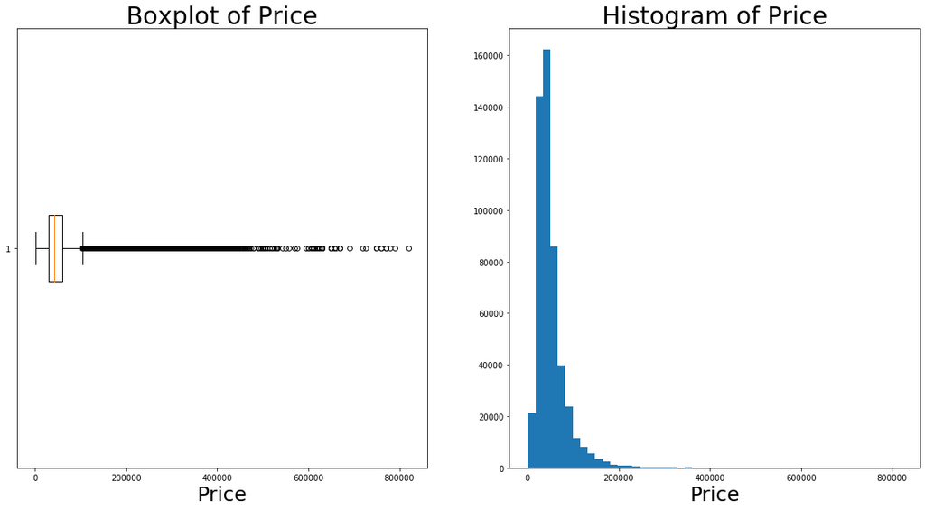

```python
#2-1.거래가격분포 확인
firstplot = plt.figure(figsize = (20,10))
axes1 = firstplot.add_subplot(1,2,1)
axes2 = firstplot.add_subplot(1,2,2)

axes1.set_title('Boxplot of Price',fontsize = 30)  #플랏 제목도 달고, 폰트 사이즈도 지정
axes1.boxplot(data['price'],vert = False)   #첫번째 플랏에는 boxplot, 가로로 눕히고
axes1.set_xlabel('Price',fontsize = 25)

axes2.hist(data['price'],50)   #두번째 플랏은 히스토그램 #숫자에 따라 y축의 분포가 달라짐.
axes2.set_title('Histogram of Price',fontsize = 30)
axes2.set_xlabel('Price',fontsize = 25)
```

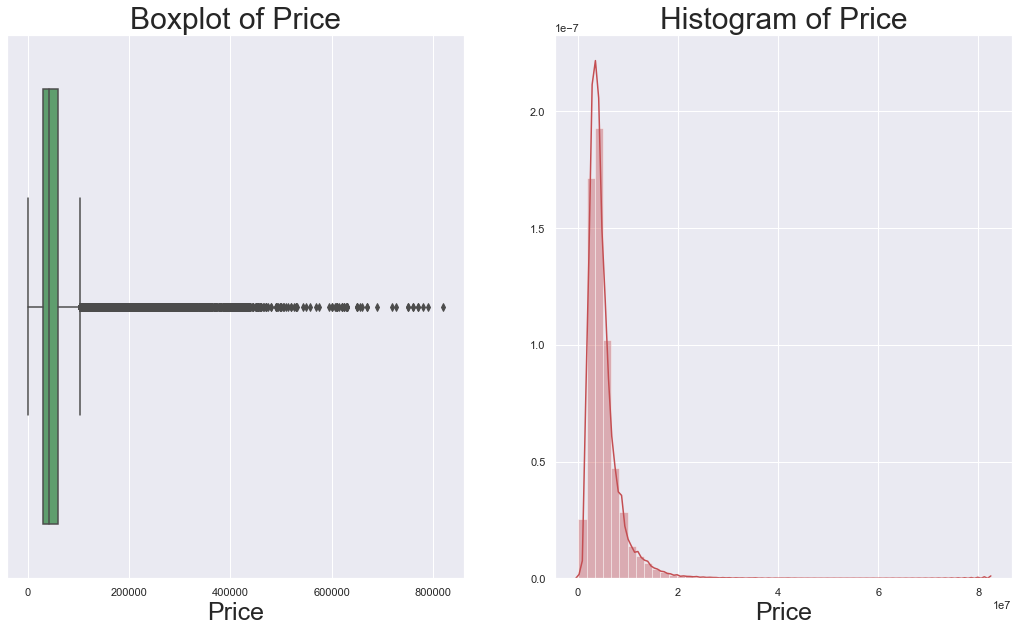

```python
sns.set(font_scale = 1)  #폰트사이즈를 전체적으로 키워준다.
fig, axs = plt.subplots(ncols = 2, figsize = (18,10))  #서브플랏을 1행2열로 분할하고
ax_1 = sns.boxplot(y= data['price'],orient='h',color = 'g' , ax=axs[0])

ax_1.set_title('Boxplot of Price',fontsize = 30)
ax_1.set_xlabel('Price',fontsize = 25)


# ax_1.xaxis.grid(True) # Show the vertical gridlines -> sns.set하니까 배경 같아짐.

ax_2 = sns.distplot(data['price']*100,bins = 50,color = 'r',ax=axs[1])  # 1e - 5가 다름.
ax_2.set_title('Histogram of Price',fontsize = 30)
ax_2.set_xlabel('Price',fontsize = 25)

# ax_2.yaxis.grid(True)
# ax_2.xaxis.grid(True)
```

# 2.2 거래연도별 분포 확인

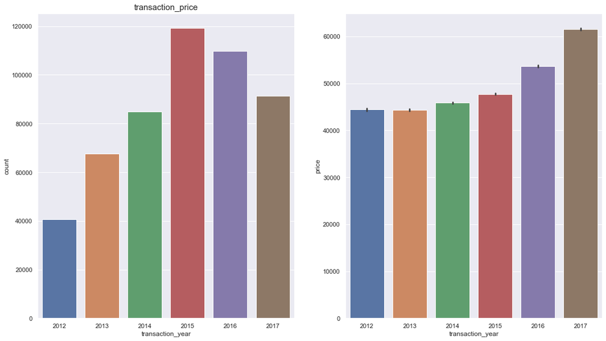

```python
#2.2 거래연도 분포 확인
fig, axs = plt.subplots(ncols = 2, figsize = (18,10))
sns.set(font_scale = 1)
price_df = data.groupby(by =['transaction_year']).size().reset_index(name='count')
price_df
ax1 = sns.barplot(x = 'transaction_year',y = 'count', data=price_df,ax = axs[0])
ax1.set_title('transaction_count',fontsize = 15)

#거래연도별 가격분포 확인
ax2 = sns.barplot(x = 'transaction_year',y = 'price', data=data,ax = axs[1])
ax1.set_title('transaction_price',fontsize = 15)
```

# 2.3 층별 확인

층이 낮을 수록 거래 횟수가 많은 것을 보니 층이 낮은 매물이 원래 데이터상 많았다거나 층이 낮을수록 거래량이 많다는 것을 알 수 있고, 절대적이진 않지만, 추이상 높은 층일 수록 가격이 상승하는 모습을 보였다가, 일정 수준의 층을 넘으면 다시 가격이 떨어지는 추이를 볼 수 있습니다.

```
[[]]
```

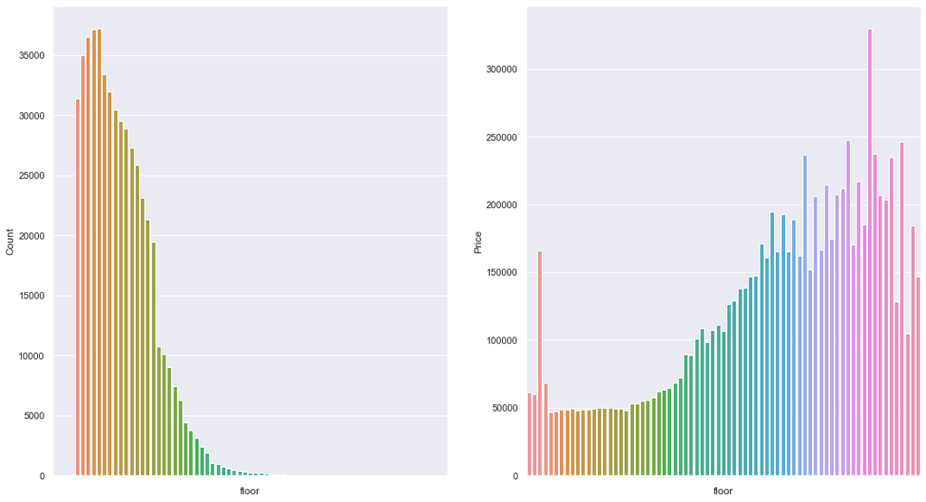

```python
#2.3 층 분포 확인/ 층별 가격 분포 확인
fig, axs = plt.subplots(ncols = 2, figsize = (18,10))
sns.set(font_scale = 1)

floor_df = data.groupby(by =['floor']).size().reset_index(name='Count')
floor_df
fplot1 = sns.barplot(x = 'floor',y = 'Count', data=floor_df,ax = axs[0])
fplot1.set(xticklabels=[])  #x축 값 제거
# 층별 가격 분포 확인
floor_price = data.groupby(by = ['floor'])['price'].mean().reset_index(name='Price')
floor_price
fplot2 = sns.barplot(x = 'floor',y = 'Price', data=floor_price,ax = axs[1])
fplot2.set(xticklabels=[])
```

# 2.4 완공연도별 분포 확인

완공연도수가 최신일수록 거래량이 일정연도 전까지는 증가하다가 오히려 가장 최신의 아파트들에서는 거래량이 많이 없었고, 완공연도별로 보았을 때, 가격은 선형적으로 감소하지는 않았다. 최신의 아파트들이 좀 더 낮은 가격대를 형성하고 있긴하지만, 선형적으로 과거의 연도 아파트일수록 가격이 비싸다라고 말할 수는 없다.

```
[[]]
```

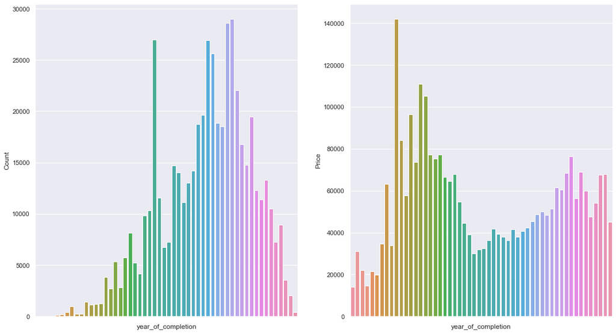

```python
#2.4 완공연도 분포 확인 / 완공 연도별 가격 분포 확인
#완공연도별 거래 횟수의 분포
fig, axs = plt.subplots(ncols = 2, figsize = (18,10))
sns.set(font_scale = 1)

complete_df = data.groupby(by =['year_of_completion']).size().reset_index(name='Count')
complete_df
Cplot1 = sns.barplot(x = 'year_of_completion',y = 'Count', data=complete_df,ax = axs[0])
Cplot1.set(xticklabels=[])  #x축 값 제거

#완공연도별 평균거래가격의 분포
complete_price = data.groupby(by = ['year_of_completion'])['price'].mean().reset_index(name='Price')
complete_price
Cplot2 = sns.barplot(x = 'year_of_completion',y = 'Price', data=complete_price,ax = axs[1])
Cplot2.set(xticklabels=[])
```

# 3.1 연차가 오래 될 수록 거래가격이 높을까?

연자로 계산한 것이므로 위의 그래프에서 좌우가 반대된 형태를 띈다. 아파트 연차 말고도, 아파트가 위치한 지역 혹은 역세권 등 위치에 따라서 가격의 차이가 있을것 같은 생각이 들어 dong변수를 이용하여 강서,강남,강북,강동 이런식의 변수를 만들어 보면 좋을 것 같다.

```python
##Chapter3.파생변수 새성
#3.1 아파트 연차 변수 생성
# dat['until_trans'] = 2021- dat['year_of_completion']
data.loc[:,'until_trans'] = 2021- data['year_of_completion']
data.head()
```

|  | dong | apt | addr_kr | exclusive_use_area | year_of_completion | transaction_year_month | transaction_date | floor | price | transaction_year | transaction_month | until_trans |
| --- | --- | --- | --- | --- | --- | --- | --- | --- | --- | --- | --- | --- |
| 0 | 사직동 | 광화문풍림스페이스본(9-0) | 사직동 9 광화문풍림스페이스본(9-0) | 95.88 | 2008 | 201201 | 1~10 | 6 | 70000 | 2012 | 1 | 13 |
| 1 | 사직동 | 광화문풍림스페이스본(9-0) | 사직동 9 광화문풍림스페이스본(9-0) | 108.55 | 2008 | 201201 | 11~20 | 11 | 100500 | 2012 | 1 | 13 |
| 2 | 사직동 | 광화문풍림스페이스본(9-0) | 사직동 9 광화문풍림스페이스본(9-0) | 94.51 | 2008 | 201201 | 11~20 | 1 | 65800 | 2012 | 1 | 13 |
| 3 | 수송동 | 로얄팰리스스위트 | 수송동 85 로얄팰리스스위트 | 42.87 | 2005 | 201201 | 1~10 | 8 | 30500 | 2012 | 1 | 16 |
| 4 | 수송동 | 로얄팰리스스위트 | 수송동 85 로얄팰리스스위트 | 39.67 | 2005 | 201201 | 21~31 | 15 | 30500 | 2012 | 1 | 16 |

```
[[]]
```

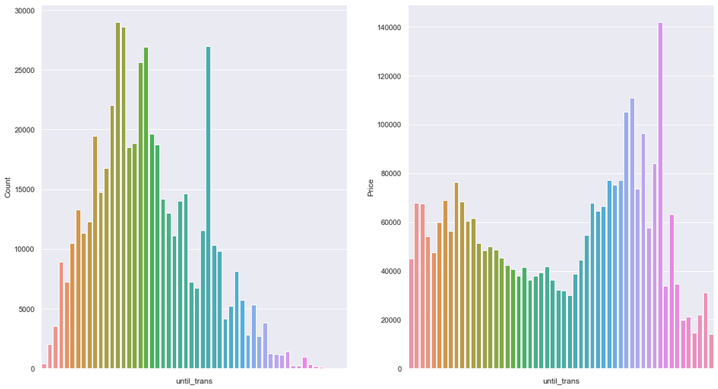

```python
#연차별 거래 횟수의 분포
fig, axs = plt.subplots(ncols = 2, figsize = (18,10))
sns.set(font_scale = 1)

until_df = data.groupby(by =['until_trans']).size().reset_index(name='Count')
until_df
Uplot1 = sns.barplot(x = 'until_trans',y = 'Count', data=until_df,ax = axs[0])
Uplot1.set(xticklabels=[])  #x축 값 제거

#연차별 평균거래가격의 분포
until_price = data.groupby(by = ['until_trans'])['price'].mean().reset_index(name='Price')
until_price
Uplot2 = sns.barplot(x = 'until_trans',y = 'Price', data=until_price,ax = axs[1],ci = 'sd') #erro_Bar가 왜 안생길까요.. 왜 나는 default가 none이야...........................
Uplot2.set(xticklabels=[])
```

```python
#3.2 거래 일 변수 값 변환
conditions = (data['transaction_date'] == '21~28')| (data['transaction_date'] == '21~29')| (data['transaction_date'] == '21~30')| (data['transaction_date'] == '21~31')

data['transaction_date'] = np.where(data['transaction_date'] == '1~10',0,np.where(data['transaction_date'] == '11~20',1,np.where(conditions,2,data['transaction_date'])))
data['transaction_date']
```

```
0         0
1         1
2         1
3         0
4         2
         ..
513523    1
513524    2
513525    2
513526    2
513527    2
Name: transaction_date, Length: 513528, dtype: object
```

```python
#3.3 월 변수와 10일 단위 변수 통합
data['transaction_month_date'] = data['transaction_month'] * 3 + data['transaction_date']
```

# 3.5 - 삼각변환의 장점

삼각변환을 하지 않고, dummy나 label인코딩을 하면 주기성을 발견하기 어렵고, 그렇게 되면 규칙성을 발견할 수 없어서 시계열의 추세나 주기 등을 제거하는 처리를 제대로 못하게 된다. 그러면 결과적으로 좋지 않은 분석 결과를 얻게 된다.

```python
#3.4 연도별 주기성을 위한 파생변수 생성(삼각변환)
import math
data['transaction_month_date'] = data['transaction_month_date'].astype(float)
data['sin_date'] = np.sin((2*np.pi)/30*data['transaction_month_date'])
data['cos_date']  = np.cos((2*np.pi)/30*data['transaction_month_date'])
data.info()
```

```
<class 'pandas.core.frame.DataFrame'>
RangeIndex: 513528 entries, 0 to 513527
Data columns (total 15 columns):
 #   Column                  Non-Null Count   Dtype
---  ------                  --------------   -----
 0   dong                    513528 non-null  object
 1   apt                     513528 non-null  object
 2   addr_kr                 513528 non-null  object
 3   exclusive_use_area      513528 non-null  float64
 4   year_of_completion      513528 non-null  int64
 5   transaction_year_month  513528 non-null  object
 6   transaction_date        513528 non-null  object
 7   floor                   513528 non-null  int64
 8   price                   513528 non-null  int64
 9   transaction_year        513528 non-null  int64
 10  transaction_month       513528 non-null  int64
 11  until_trans             513528 non-null  int64
 12  transaction_month_date  513528 non-null  float64
 13  sin_date                513528 non-null  float64
 14  cos_date                513528 non-null  float64
dtypes: float64(4), int64(6), object(5)
memory usage: 58.8+ MB
```

```python
#불필요한 변수 제거
data = data.drop([data.columns[4],data.columns[5],data.columns[6],data.columns[10],data.columns[12]],axis = 1)
data
```

|  | dong | apt | addr_kr | exclusive_use_area | floor | price | transaction_year | until_trans | sin_date | cos_date |
| --- | --- | --- | --- | --- | --- | --- | --- | --- | --- | --- |
| 0 | 사직동 | 광화문풍림스페이스본(9-0) | 사직동 9 광화문풍림스페이스본(9-0) | 95.88 | 6 | 70000 | 2012 | 13 | 0.587785 | 0.809017 |
| 1 | 사직동 | 광화문풍림스페이스본(9-0) | 사직동 9 광화문풍림스페이스본(9-0) | 108.55 | 11 | 100500 | 2012 | 13 | 0.743145 | 0.669131 |
| 2 | 사직동 | 광화문풍림스페이스본(9-0) | 사직동 9 광화문풍림스페이스본(9-0) | 94.51 | 1 | 65800 | 2012 | 13 | 0.743145 | 0.669131 |
| 3 | 수송동 | 로얄팰리스스위트 | 수송동 85 로얄팰리스스위트 | 42.87 | 8 | 30500 | 2012 | 16 | 0.587785 | 0.809017 |
| 4 | 수송동 | 로얄팰리스스위트 | 수송동 85 로얄팰리스스위트 | 39.67 | 15 | 30500 | 2012 | 16 | 0.866025 | 0.500000 |
| ... | ... | ... | ... | ... | ... | ... | ... | ... | ... | ... |
| 513523 | 강일동 | 고덕리엔파크2단지 | 강일동 717 고덕리엔파크2단지 | 59.72 | 9 | 53000 | 2017 | 10 | 0.743145 | 0.669131 |
| 513524 | 강일동 | 강일리버파크3단지 | 강일동 674 강일리버파크3단지 | 59.87 | 12 | 53000 | 2017 | 12 | 0.866025 | 0.500000 |
| 513525 | 강일동 | 강일리버파크3단지 | 강일동 674 강일리버파크3단지 | 84.74 | 3 | 56500 | 2017 | 12 | 0.866025 | 0.500000 |
| 513526 | 강일동 | 강일리버파크1단지 | 강일동 665 강일리버파크1단지 | 84.74 | 9 | 55500 | 2017 | 12 | 0.866025 | 0.500000 |
| 513527 | 강일동 | 고덕리엔파크2단지 | 강일동 717 고덕리엔파크2단지 | 84.98 | 8 | 63750 | 2017 | 10 | 0.866025 | 0.500000 |

513528 rows × 10 columns

```python
# ##Chapter4. 텍스트 데이터 다루기   -> 각각 해보다가 영어도 빼야하는 것을 나중에 알고 밑에 걸로 한글만 추출하기!
# apt = dat['apt']
# apt = apt.str.replace(pat = r'[^\w]',repl='',regex = True)   #특수기호 없애기

# import re

# B = []
# for i in range(len(apt)):
#     el = re.sub(r'[0-9]+', '',str(apt.iloc[i]))
#     B.append(el)   #숫자제거
```

```python
##Chapter 4. 텍스트 데이터 다루기
#한글만 추출하기
import re

def test():
    s  = data['apt']
    B = []
    for i in range(len(s)):

        hangul = re.compile('[^ ㄱ-ㅣ가-힣]+') # 한글과 띄어쓰기를 제외한 모든 글자  or re.compile('[^ \u3131-\u3163\uac00-\ud7a3]+')
        B.append(hangul.sub('', s.iloc[i])) # 한글과 띄어쓰기를 제외한 모든 부분을 제거


#       result = hangul.findall(s.iloc[i])# 무슨 글자가 빠졌는지 알고 싶을때,
    data['apt'] = B
test()
```

```python
#아파트 목록 확인용
# df = data['apt']
# df.to_csv('C:/Users/user/Desktop/apt.csv', index=False, encoding='cp949')
```

```python
#4.2 아파트 이름DTM - 아파트 이름에 대한 문서 단어행렬
from sklearn.feature_extraction.text import CountVectorizer

Cvectorizer = CountVectorizer(min_df = 5)
Cvectorizer.fit(data['apt'])
# Printing the identified Unique words along with their indices
# print("Vocabulary: ", Cvectorizer.vocabulary_)

# Encode the Document
Cvector = Cvectorizer.transform(data['apt'])


# Cvector.toarray() #-> MemoryError: Unable to allocate 15.4 GiB for an array with shape (513528, 4023) and data type int64 오우..해결(근데 밑에거랑 같이 하면 안돌아가서 둘 중에 하나만 택할 수 있습니다..)
```

```python
from sklearn.feature_extraction.text import TfidfVectorizer

Tvectorizer = TfidfVectorizer(min_df = 5)
Tvectorizer.fit(data['apt'])
# Printing the identified Unique words along with their indices
# print("Vocabulary: ", Tvectorizer.vocabulary_)

# Encode the Document
Tvector = Tvectorizer.transform(data['apt'])
# Tvector.toarray()
```

# 4.4 질문

차원이 너무 많아지지 않을까요..? 또... 위에만 돌려도 메모리가 부족하다는 오류가 있어서 돌리기 힘들 것 같습니다. 아파트명 별로 구분되는 단어들만 추출해서 아파트당 단어 하나만 고유값으로 남기고, 예를들면 캐슬, 타운, 타워 이런식으로? 남기고 그걸로 인코딩을 해주면 어떨까 하는데.. 구체적인 방법은 잘 모르겠습니다,,,

```python
#5. 인코딩
data = data.drop(columns = ['addr_kr'])
```

# 5.1 원핫인코딩

```python
#5.1 원핫 인코딩
pd.get_dummies(data['dong'], prefix='onehot_')
pd.get_dummies(data['apt'], prefix='onehot_')
```

|  | onehot__ | onehot__ | onehot__ | onehot__ 아파트 | onehot__ 대학마을 | onehot__ 동 | onehot__ 서울역 리가 | onehot__ 푸른아파트 | onehot__가락그랑밸리 | onehot__가락금호아파트 | ... | onehot__힐캐슬 | onehot__힐타운 | onehot__힐타워 | onehot__힐탑 | onehot__힐탑아파트차 | onehot__힐탑이루미 | onehot__힐탑트레져동 | onehot__힐튼 | onehot__힐튼빌리지차 | onehot__힐하우스 |
| --- | --- | --- | --- | --- | --- | --- | --- | --- | --- | --- | --- | --- | --- | --- | --- | --- | --- | --- | --- | --- | --- |
| 0 | 0 | 0 | 0 | 0 | 0 | 0 | 0 | 0 | 0 | 0 | ... | 0 | 0 | 0 | 0 | 0 | 0 | 0 | 0 | 0 | 0 |
| 1 | 0 | 0 | 0 | 0 | 0 | 0 | 0 | 0 | 0 | 0 | ... | 0 | 0 | 0 | 0 | 0 | 0 | 0 | 0 | 0 | 0 |
| 2 | 0 | 0 | 0 | 0 | 0 | 0 | 0 | 0 | 0 | 0 | ... | 0 | 0 | 0 | 0 | 0 | 0 | 0 | 0 | 0 | 0 |
| 3 | 0 | 0 | 0 | 0 | 0 | 0 | 0 | 0 | 0 | 0 | ... | 0 | 0 | 0 | 0 | 0 | 0 | 0 | 0 | 0 | 0 |
| 4 | 0 | 0 | 0 | 0 | 0 | 0 | 0 | 0 | 0 | 0 | ... | 0 | 0 | 0 | 0 | 0 | 0 | 0 | 0 | 0 | 0 |
| ... | ... | ... | ... | ... | ... | ... | ... | ... | ... | ... | ... | ... | ... | ... | ... | ... | ... | ... | ... | ... | ... |
| 513523 | 0 | 0 | 0 | 0 | 0 | 0 | 0 | 0 | 0 | 0 | ... | 0 | 0 | 0 | 0 | 0 | 0 | 0 | 0 | 0 | 0 |
| 513524 | 0 | 0 | 0 | 0 | 0 | 0 | 0 | 0 | 0 | 0 | ... | 0 | 0 | 0 | 0 | 0 | 0 | 0 | 0 | 0 | 0 |
| 513525 | 0 | 0 | 0 | 0 | 0 | 0 | 0 | 0 | 0 | 0 | ... | 0 | 0 | 0 | 0 | 0 | 0 | 0 | 0 | 0 | 0 |
| 513526 | 0 | 0 | 0 | 0 | 0 | 0 | 0 | 0 | 0 | 0 | ... | 0 | 0 | 0 | 0 | 0 | 0 | 0 | 0 | 0 | 0 |
| 513527 | 0 | 0 | 0 | 0 | 0 | 0 | 0 | 0 | 0 | 0 | ... | 0 | 0 | 0 | 0 | 0 | 0 | 0 | 0 | 0 | 0 |

513528 rows × 5107 columns

# 5.2 레이블 인코딩이 적절한가?

2.2 그래프를 보았을 때, 연도별로 값들이 막대그래프로 잘 표현이 돼있고, 연도를 label로 바꿔주면 연도처럼 크기 차이(최신인지 아닌지)가 생기기 때문에 2.2그래프처럼 표현할 때 적절한 인코딩일 것 같다는 생각이 듭니다.

```python
#5.2 레이블 인코딩 - transaction_year
from sklearn.preprocessing import LabelEncoder  #레이블 인코딩
labelencoder = LabelEncoder()
data['transaction_year'] = labelencoder.fit_transform(data['transaction_year'])
data
```

|  | dong | apt | exclusive_use_area | floor | price | transaction_year | until_trans | sin_date | cos_date |
| --- | --- | --- | --- | --- | --- | --- | --- | --- | --- |
| 0 | 사직동 | 광화문풍림스페이스본 | 95.88 | 6 | 70000 | 0 | 13 | 0.587785 | 0.809017 |
| 1 | 사직동 | 광화문풍림스페이스본 | 108.55 | 11 | 100500 | 0 | 13 | 0.743145 | 0.669131 |
| 2 | 사직동 | 광화문풍림스페이스본 | 94.51 | 1 | 65800 | 0 | 13 | 0.743145 | 0.669131 |
| 3 | 수송동 | 로얄팰리스스위트 | 42.87 | 8 | 30500 | 0 | 16 | 0.587785 | 0.809017 |
| 4 | 수송동 | 로얄팰리스스위트 | 39.67 | 15 | 30500 | 0 | 16 | 0.866025 | 0.500000 |
| ... | ... | ... | ... | ... | ... | ... | ... | ... | ... |
| 513523 | 강일동 | 고덕리엔파크단지 | 59.72 | 9 | 53000 | 5 | 10 | 0.743145 | 0.669131 |
| 513524 | 강일동 | 강일리버파크단지 | 59.87 | 12 | 53000 | 5 | 12 | 0.866025 | 0.500000 |
| 513525 | 강일동 | 강일리버파크단지 | 84.74 | 3 | 56500 | 5 | 12 | 0.866025 | 0.500000 |
| 513526 | 강일동 | 강일리버파크단지 | 84.74 | 9 | 55500 | 5 | 12 | 0.866025 | 0.500000 |
| 513527 | 강일동 | 고덕리엔파크단지 | 84.98 | 8 | 63750 | 5 | 10 | 0.866025 | 0.500000 |

513528 rows × 9 columns

# 5.3 레이블 인코딩

dong이랑 아파트 이름은 label을 인코딩만 하면 크기차이가 생기기 때문에 부적절할 것 같습니다.

```python
#5.2 레이블 인코딩 - dog & apt 변수
from sklearn.preprocessing import LabelEncoder  #레이블 인코딩
labelencoder = LabelEncoder()
dong_label = labelencoder.fit_transform(data['dong'])
apt_label = labelencoder.fit_transform(data['apt'])
data_label = data
data_label['dong'] = dong_label
data_label['apt'] = apt_label
data_label.head()
```

|  | dong | apt | exclusive_use_area | floor | price | transaction_year | until_trans | sin_date | cos_date |
| --- | --- | --- | --- | --- | --- | --- | --- | --- | --- |
| 0 | 130 | 331 | 95.88 | 6 | 70000 | 0 | 13 | 0.587785 | 0.809017 |
| 1 | 130 | 331 | 108.55 | 11 | 100500 | 0 | 13 | 0.743145 | 0.669131 |
| 2 | 130 | 331 | 94.51 | 1 | 65800 | 0 | 13 | 0.743145 | 0.669131 |
| 3 | 164 | 1326 | 42.87 | 8 | 30500 | 0 | 16 | 0.587785 | 0.809017 |
| 4 | 164 | 1326 | 39.67 | 15 | 30500 | 0 | 16 | 0.866025 | 0.500000 |

# 5.3 mean encoding의 장/단점

Label 값에 따른 예측 값의 평균은 Label 값에 따라 달라질 수 있다는 점을 이용하여 Label 값을 수치적으로 표현하면서도, 서로 구분할 수 있다는 점이 장점이고, 단점은 오버피팅의 문제가 있을 수 있다는 점이다.

```python
#5.3 mean encoding
# apt_mean


data.groupby(['apt'])['dong'].mean()

Mean_encoded_subject = data.groupby(['apt'])['dong'].mean().to_dict()

data['apt_mean'] =  data['apt'].map(Mean_encoded_subject)

data
```

|  | dong | apt | exclusive_use_area | floor | price | transaction_year | until_trans | sin_date | cos_date | apt_mean |
| --- | --- | --- | --- | --- | --- | --- | --- | --- | --- | --- |
| 0 | 130 | 331 | 95.88 | 6 | 70000 | 0 | 13 | 0.587785 | 0.809017 | 130.00000 |
| 1 | 130 | 331 | 108.55 | 11 | 100500 | 0 | 13 | 0.743145 | 0.669131 | 130.00000 |
| 2 | 130 | 331 | 94.51 | 1 | 65800 | 0 | 13 | 0.743145 | 0.669131 | 130.00000 |
| 3 | 164 | 1326 | 42.87 | 8 | 30500 | 0 | 16 | 0.587785 | 0.809017 | 164.00000 |
| 4 | 164 | 1326 | 39.67 | 15 | 30500 | 0 | 16 | 0.866025 | 0.500000 | 164.00000 |
| ... | ... | ... | ... | ... | ... | ... | ... | ... | ... | ... |
| 513523 | 6 | 236 | 59.72 | 9 | 53000 | 5 | 10 | 0.743145 | 0.669131 | 94.08866 |
| 513524 | 6 | 117 | 59.87 | 12 | 53000 | 5 | 12 | 0.866025 | 0.500000 | 6.00000 |
| 513525 | 6 | 117 | 84.74 | 3 | 56500 | 5 | 12 | 0.866025 | 0.500000 | 6.00000 |
| 513526 | 6 | 117 | 84.74 | 9 | 55500 | 5 | 12 | 0.866025 | 0.500000 | 6.00000 |
| 513527 | 6 | 236 | 84.98 | 8 | 63750 | 5 | 10 | 0.866025 | 0.500000 | 94.08866 |

513528 rows × 10 columns